# Meiofauna Size Spectrum & Biomass for OR1 1114, 1126

Chih-Lin Wei

2020-08-23

# 1 Construction of meiofauna size specturm

Normalized biomass size spectrum (NBSS) and individual size distribution (ISD) were computed using R package sizeSpectra (Edwards et al., 2017, Methods in Ecology and Evolution 1:57-67). A probability density function based on a bounded power law (PLB) distribution was fitted to the ISD of meiofauna using maximum likelihood estimation (MLE) to estimate the exponent b. The exponent b (determined by MLE) is equivalent to the regression slope of the NBSS; however, comparison studies by Edwards et al. (2017) concluded that MLE method is the most accurate way to estimate the slope.

For normalized biomass size spectrum (NBSS), individual size of meiofauna were binned by log2 transformation of their biomass. The total biomass of each bin was normalized by the width of the bin. The log10 normalized biomass was plotted against the log10 midpoint of the size bin; however, the regression slope (and line) was not estimated from the NBSS. Instead, the slope (and line) was estimated by a customized probability density function using maximum likelihood.

The same fitted line (with 95% confidence interval) was plotted on the individual size distribution, which ranks the body size in decreasing order to visualized the fit between the model and size data.

# 2 NBSS and ISD by habitat

## 2.1 All size classes

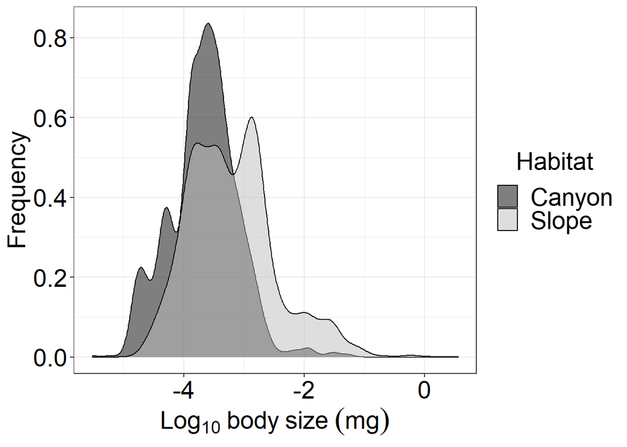

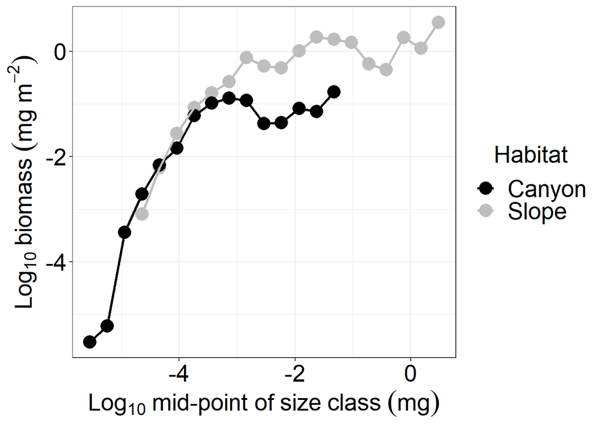

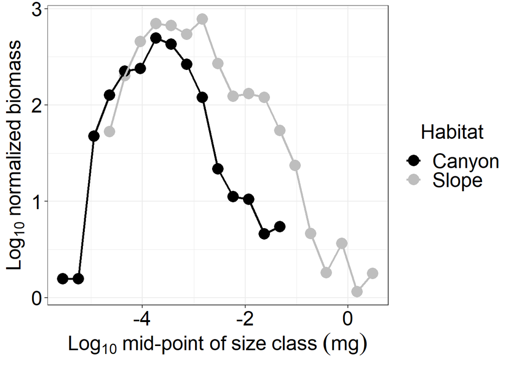

## 2.2 Size classes >= 1e-03

```
## $Slope
## $Slope$PLB.bMLE
## [1] -1.8154
##
## $Slope$PLB.MLE.bConf
## [1] -1.86717 -1.76544
##
##
## $Canyon
## $Canyon$PLB.bMLE
## [1] -2.233913
##
## $Canyon$PLB.MLE.bConf
## [1] -2.487173 -2.001833
```

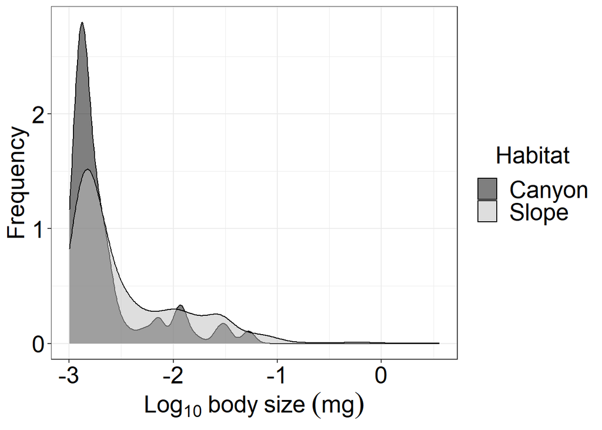

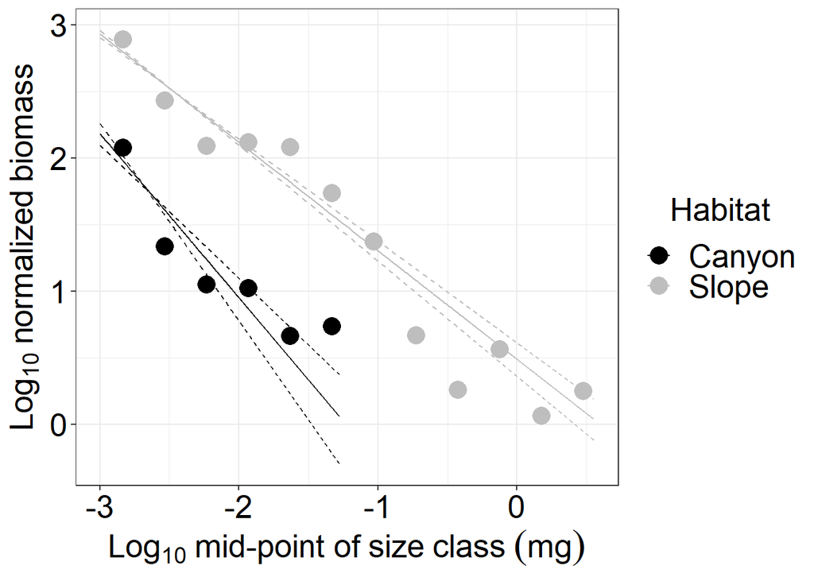

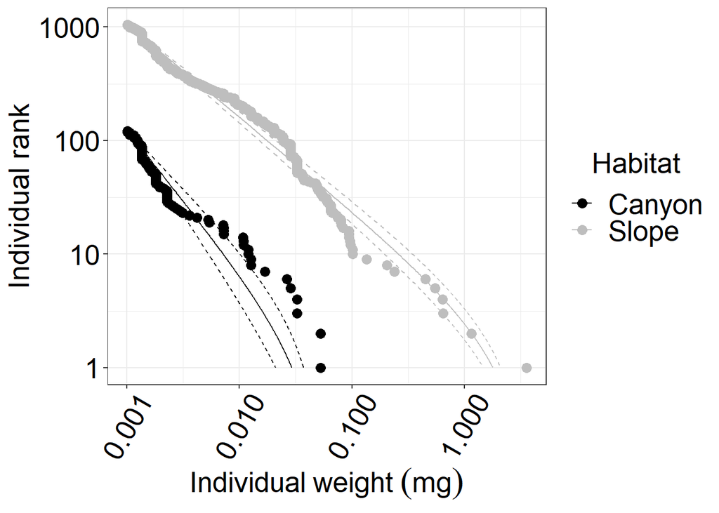

# 3 NBSS and ISD by Cruise and habitat

## 3.1 All size classes

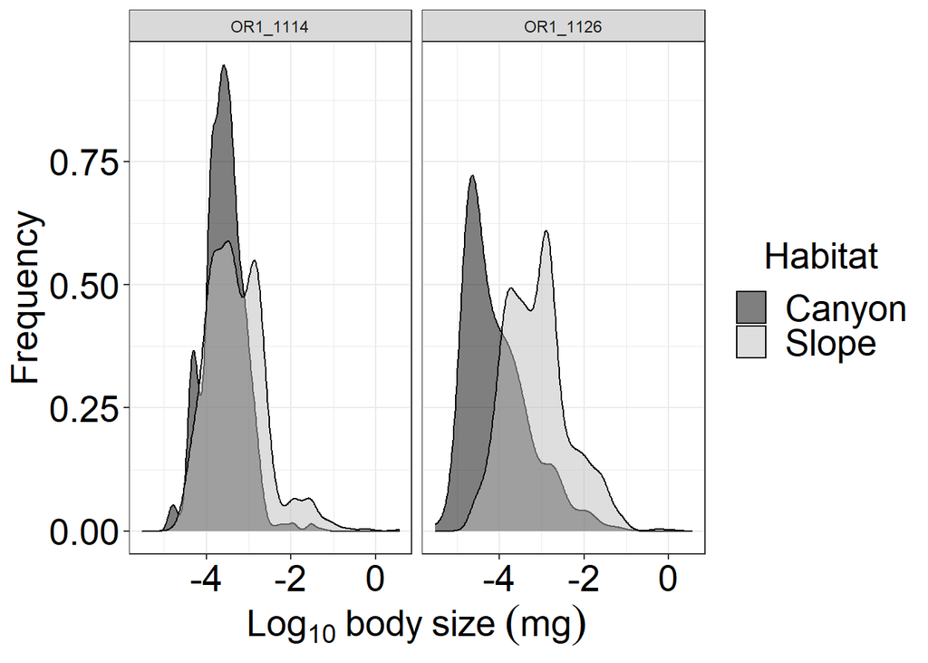

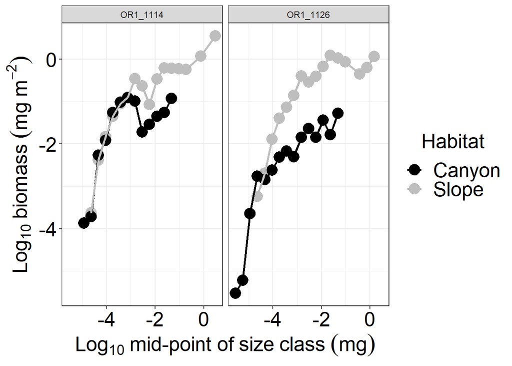

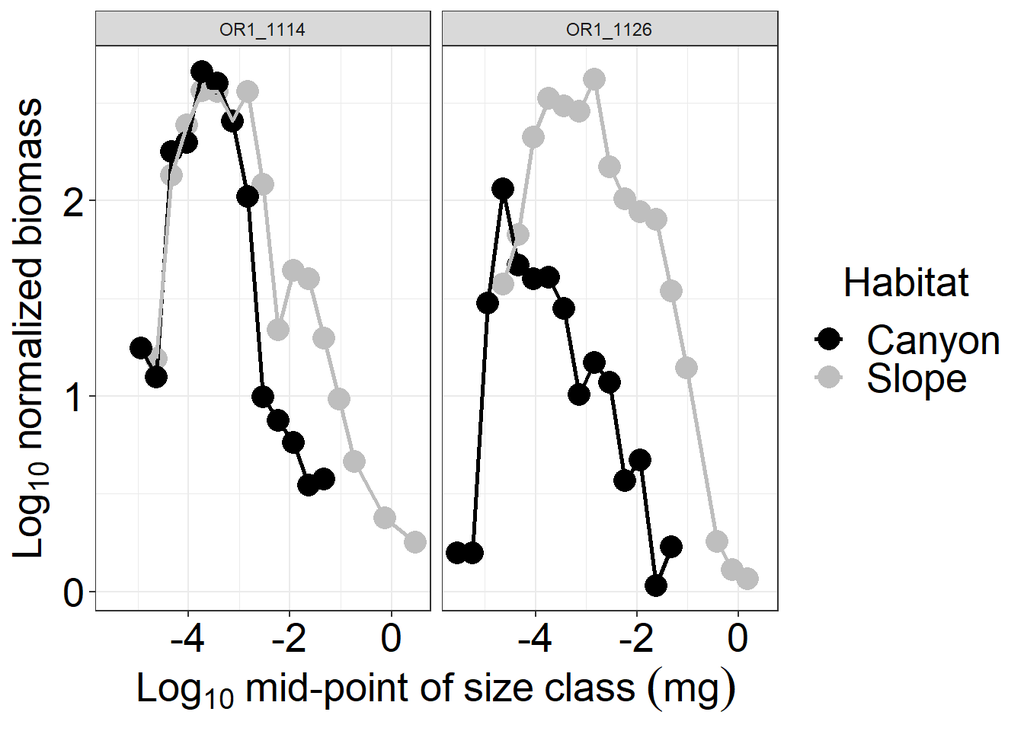

## 3.2 Size classes >= 1e-03

```
## $`OR1_1126|Slope`
## $`OR1_1126|Slope`$PLB.bMLE
## [1] -1.751125
##
## $`OR1_1126|Slope`$PLB.MLE.bConf
## [1] -1.816445 -1.688425
##
##
## $`OR1_1126|Canyon`
## $`OR1_1126|Canyon`$PLB.bMLE
## [1] -1.877067
##
## $`OR1_1126|Canyon`$PLB.MLE.bConf
## [1] -2.356897 -1.459387
##
##
## $`OR1_1114|Slope`
## $`OR1_1114|Slope`$PLB.bMLE
## [1] -1.903758
##
## $`OR1_1114|Slope`$PLB.MLE.bConf
## [1] -1.993218 -1.819338
##
##
## $`OR1_1114|Canyon`
## $`OR1_1114|Canyon`$PLB.bMLE
## [1] -2.444805
##
## $`OR1_1114|Canyon`$PLB.MLE.bConf
## [1] -2.768165 -2.154775
```

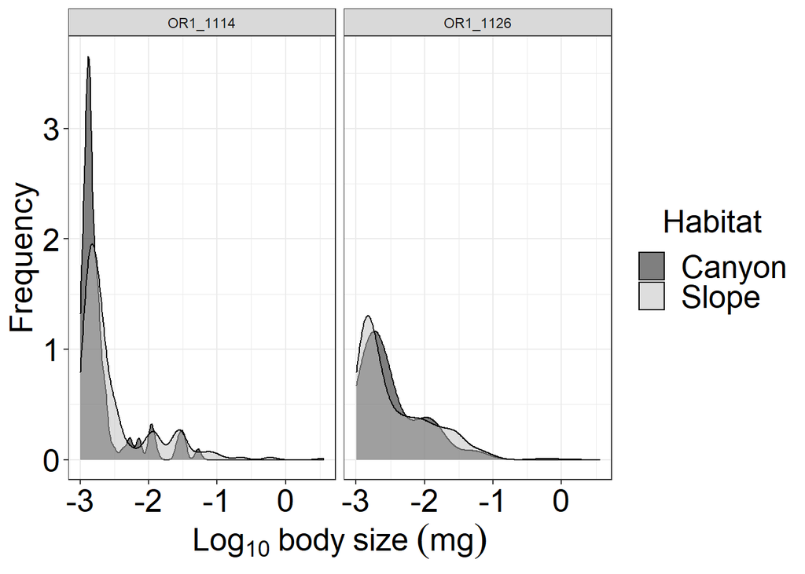

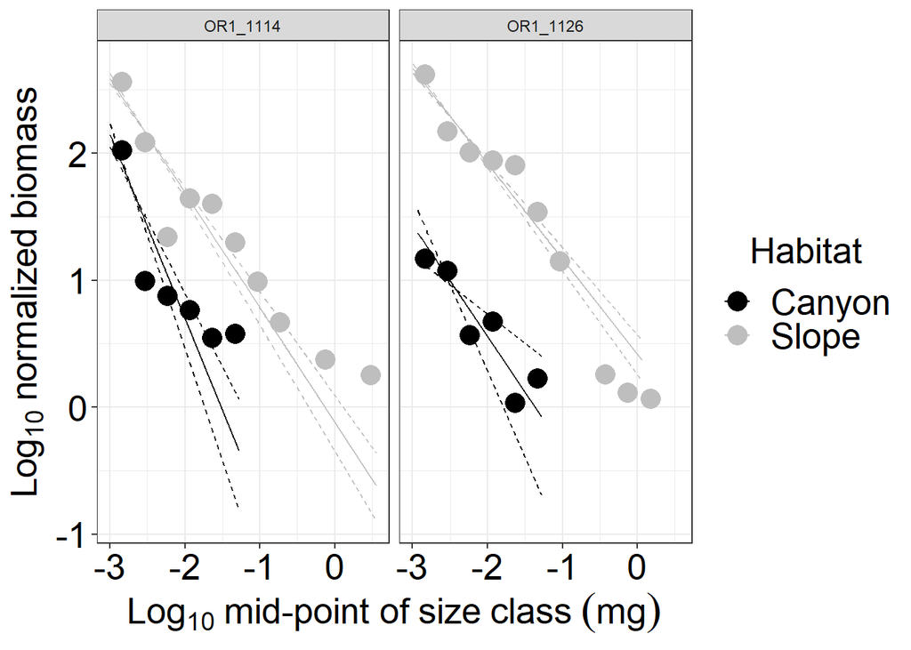

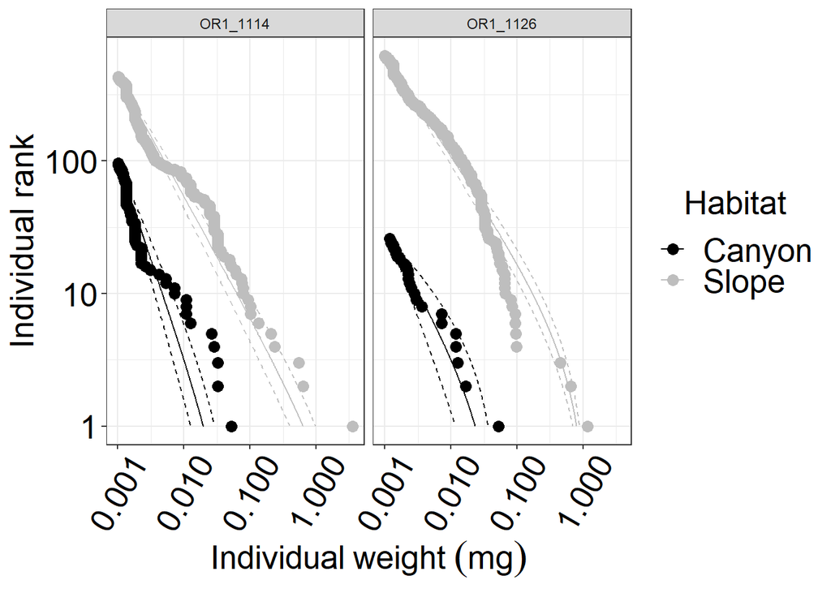

# 4 NBSS and ISD by habitat and depth strata

## 4.1 All size classes

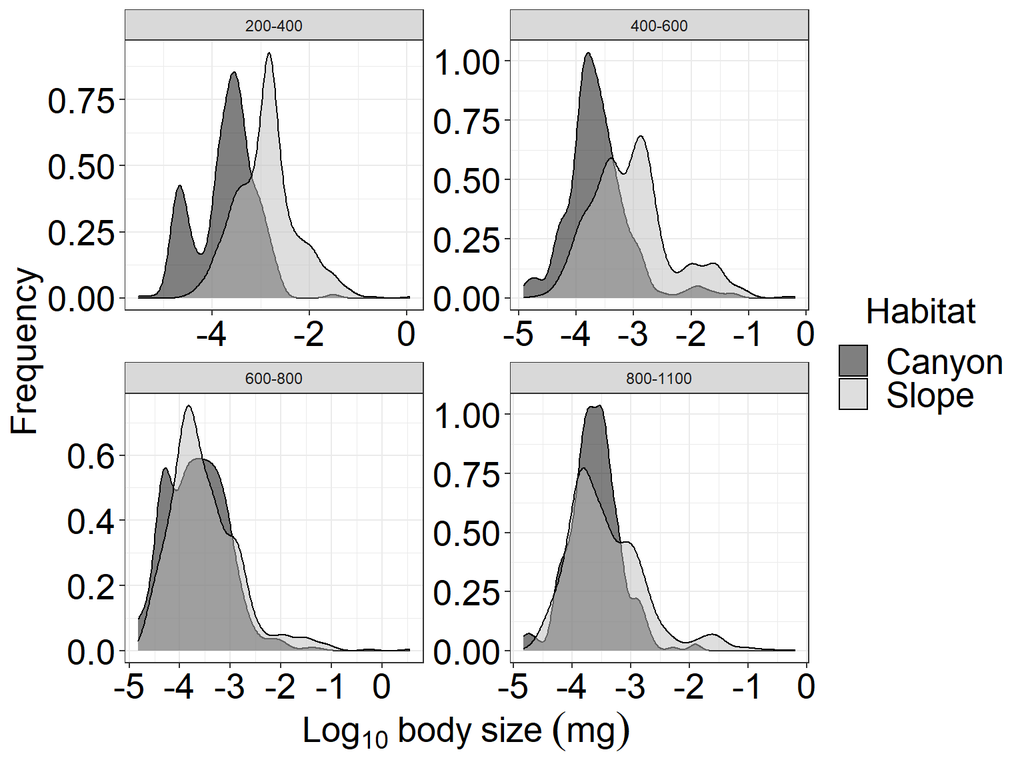

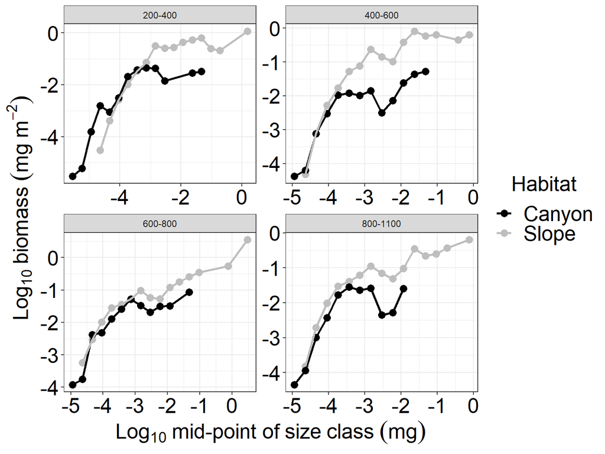

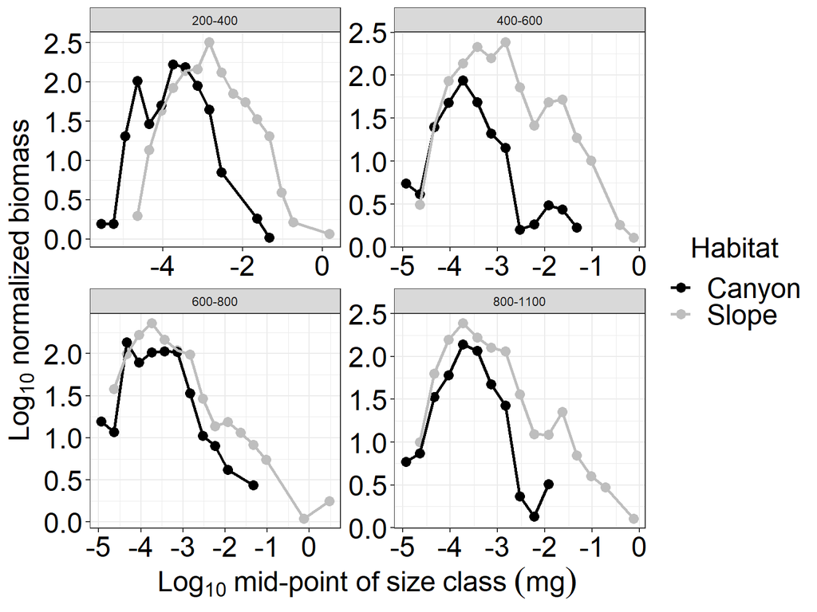

## 4.2 Size classes >= 1e-03

```
## $`Slope|200-400`
## $`Slope|200-400`$PLB.bMLE
## [1] -1.867896
##
## $`Slope|200-400`$PLB.MLE.bConf
## [1] -1.954746 -1.785506
##
##
## $`Slope|400-600`
## $`Slope|400-600`$PLB.bMLE
## [1] -1.731546
##
## $`Slope|400-600`$PLB.MLE.bConf
## [1] -1.822636 -1.645086
##
##
## $`Slope|600-800`
## $`Slope|600-800`$PLB.bMLE
## [1] -1.776378
##
## $`Slope|600-800`$PLB.MLE.bConf
## [1] -1.924998 -1.641998
##
##
## $`Slope|800-1100`
## $`Slope|800-1100`$PLB.bMLE
## [1] -1.822523
##
## $`Slope|800-1100`$PLB.MLE.bConf
## [1] -1.968653 -1.687923
```

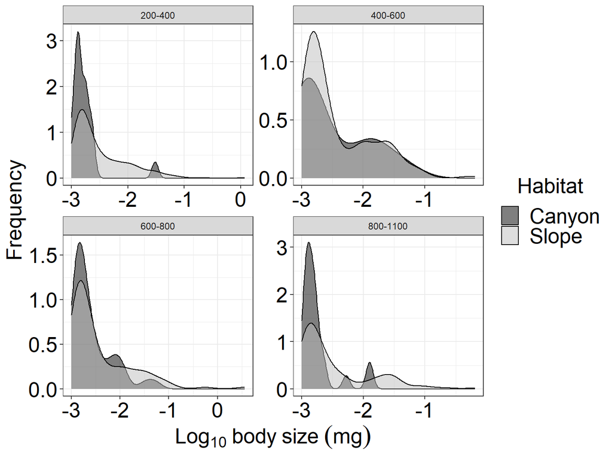

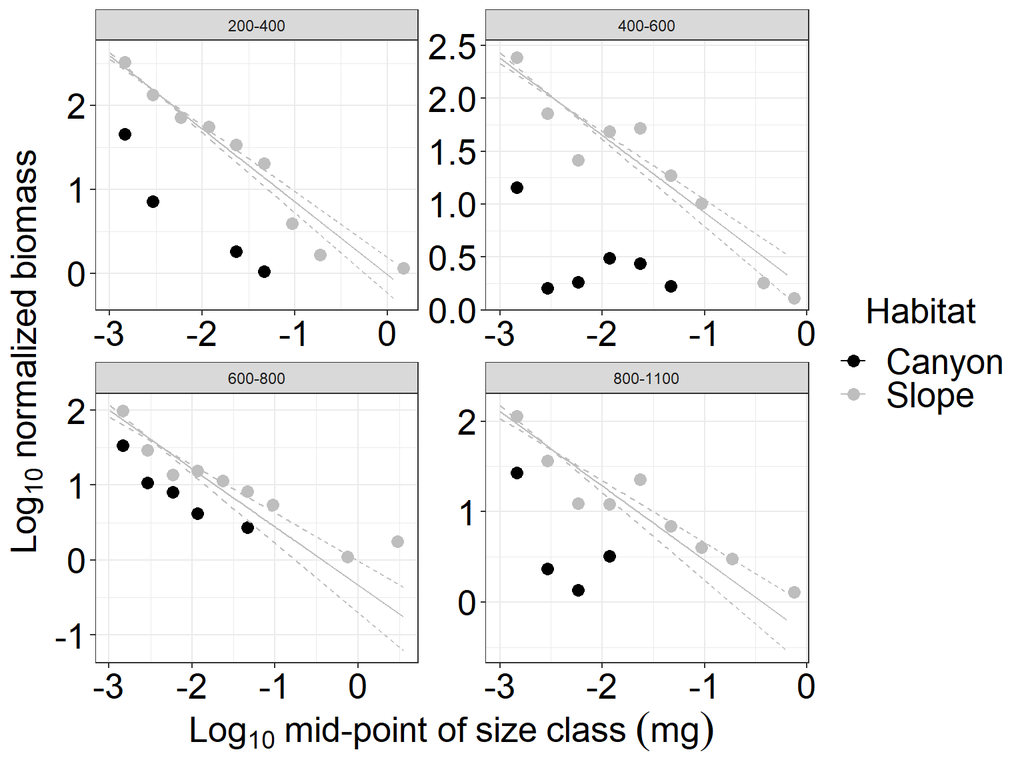

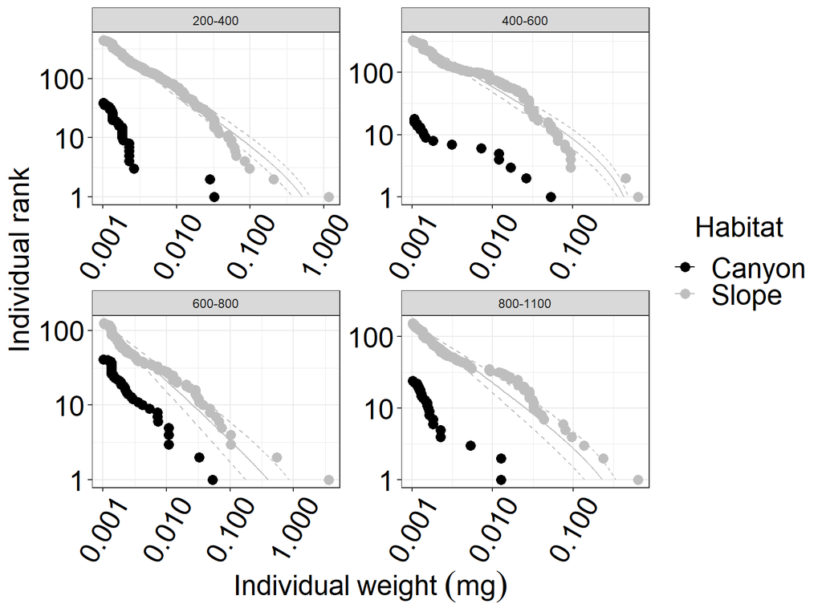

# 5 NBSS and ISD by cruise, habitat and depth strata

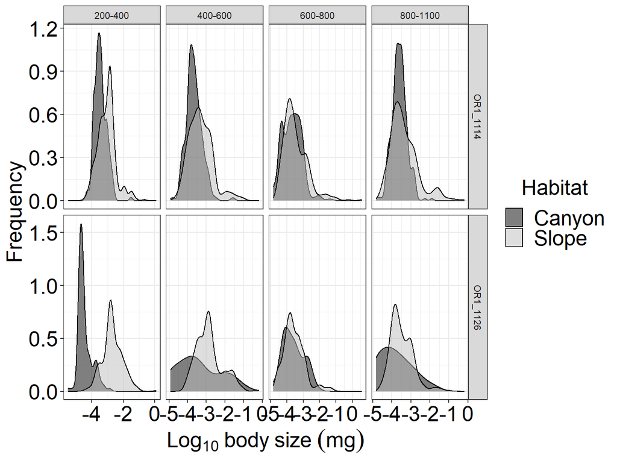

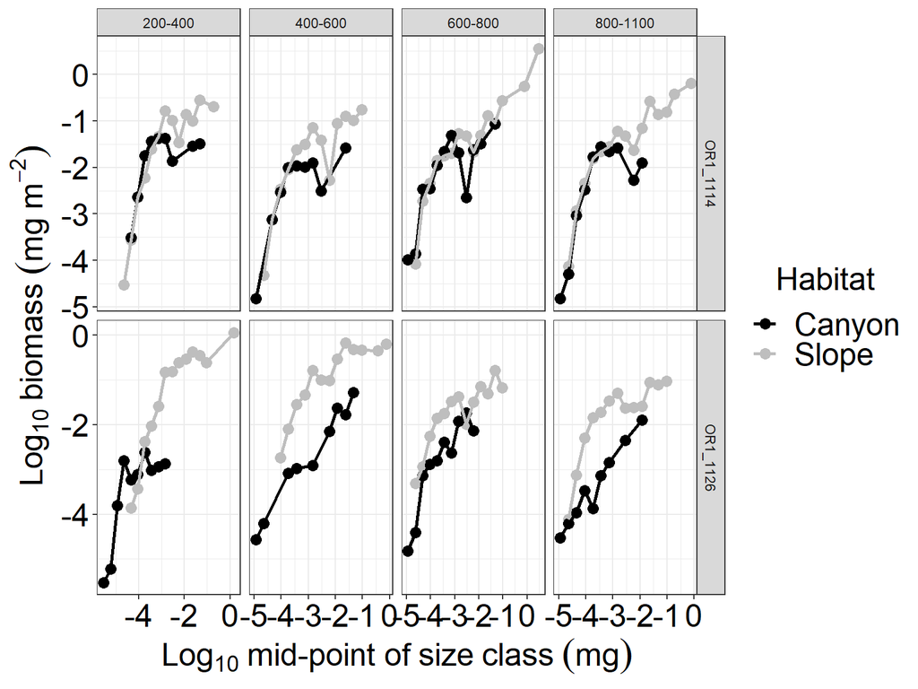

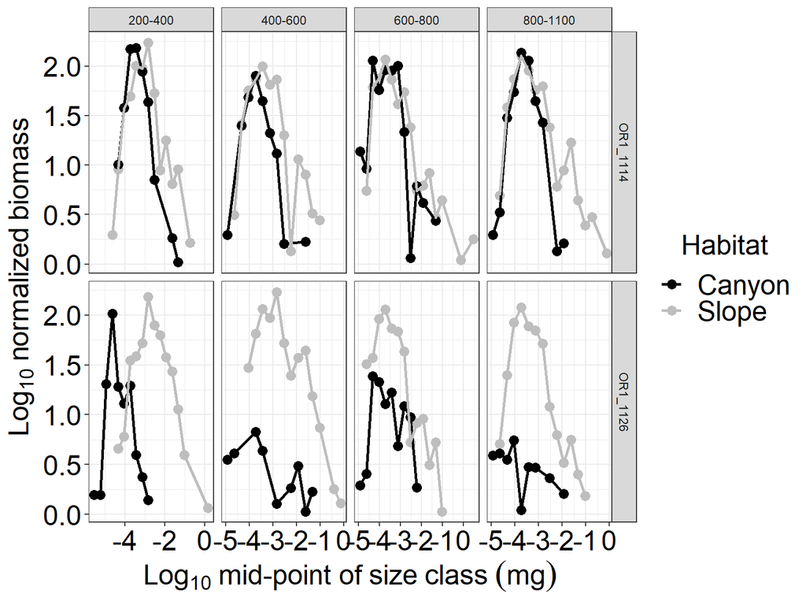

```
## $`OR1_1126|Slope|200-400`
## $`OR1_1126|Slope|200-400`$PLB.bMLE
## [1] -1.750585
##
## $`OR1_1126|Slope|200-400`$PLB.MLE.bConf
## [1] -1.852795 -1.654645
##
##
## $`OR1_1126|Slope|400-600`
## $`OR1_1126|Slope|400-600`$PLB.bMLE
## [1] -1.688128
##
## $`OR1_1126|Slope|400-600`$PLB.MLE.bConf
## [1] -1.789828 -1.592108
##
##
## $`OR1_1126|Slope|600-800`
## $`OR1_1126|Slope|600-800`$PLB.bMLE
## [1] -1.73721
##
## $`OR1_1126|Slope|600-800`$PLB.MLE.bConf
## [1] -2.02574 -1.47378
##
##
## $`OR1_1126|Slope|800-1100`
## $`OR1_1126|Slope|800-1100`$PLB.bMLE
## [1] -2.056943
##
## $`OR1_1126|Slope|800-1100`$PLB.MLE.bConf
## [1] -2.371003 -1.778933
##
##
## $`OR1_1114|Slope|200-400`
## $`OR1_1114|Slope|200-400`$PLB.bMLE
## [1] -2.115012
##
## $`OR1_1114|Slope|200-400`$PLB.MLE.bConf
## [1] -2.291752 -1.951942
##
##
## $`OR1_1114|Slope|400-600`
## $`OR1_1114|Slope|400-600`$PLB.bMLE
## [1] -1.882279
##
## $`OR1_1114|Slope|400-600`$PLB.MLE.bConf
## [1] -2.122259 -1.663289
##
##
## $`OR1_1114|Slope|600-800`
## $`OR1_1114|Slope|600-800`$PLB.bMLE
## [1] -1.740004
##
## $`OR1_1114|Slope|600-800`$PLB.MLE.bConf
## [1] -1.931204 -1.571934
##
##
## $`OR1_1114|Slope|800-1100`
## $`OR1_1114|Slope|800-1100`$PLB.bMLE
## [1] -1.695874
##
## $`OR1_1114|Slope|800-1100`$PLB.MLE.bConf
## [1] -1.865184 -1.541754
```

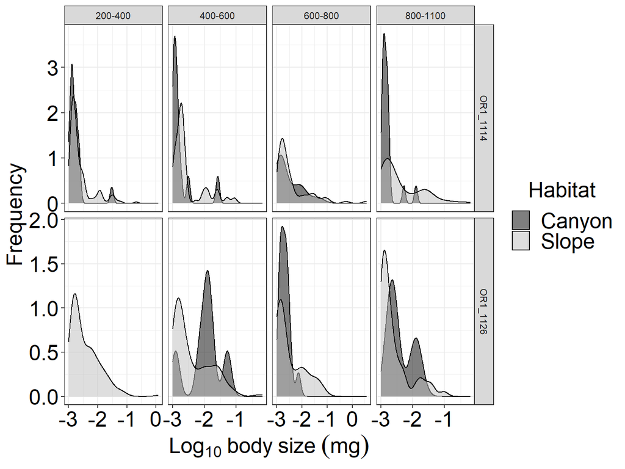

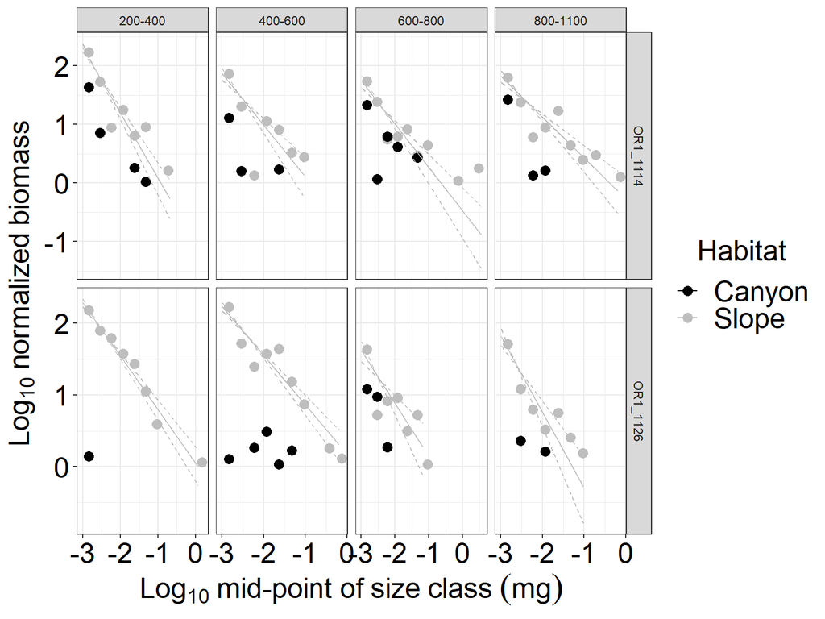

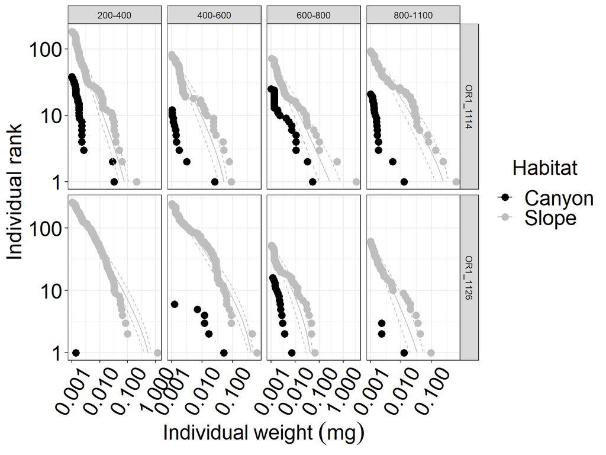

# 6 NBSS and ISD by cruise, habitat and dominant taxa

## 6.1 All size classes

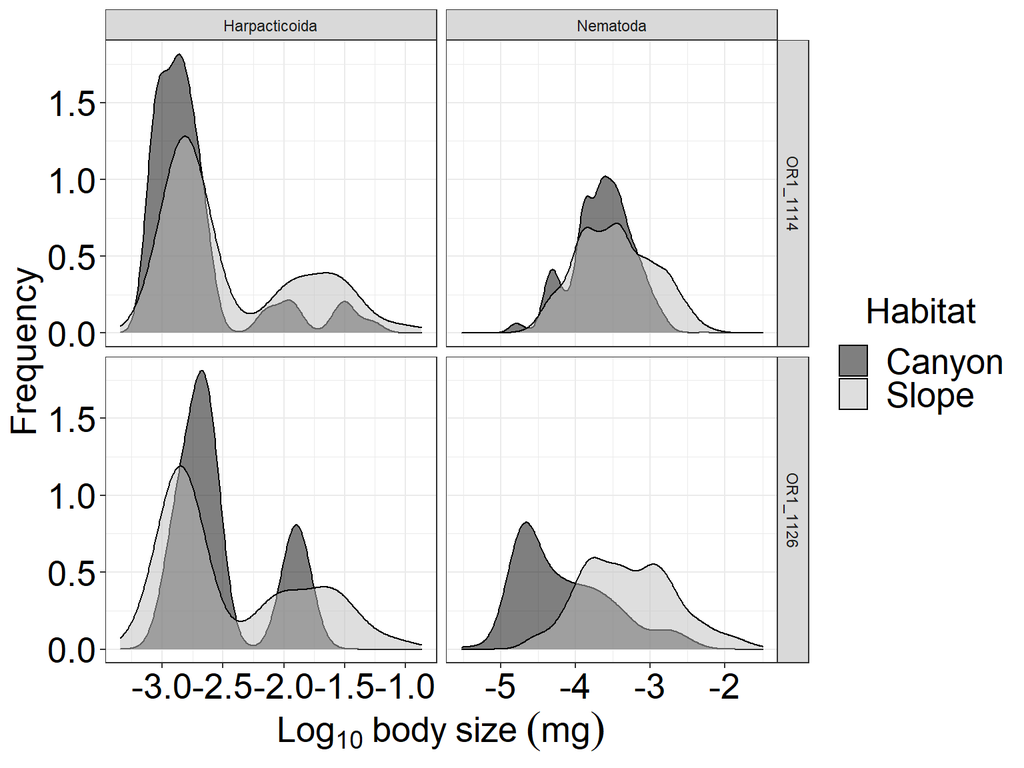

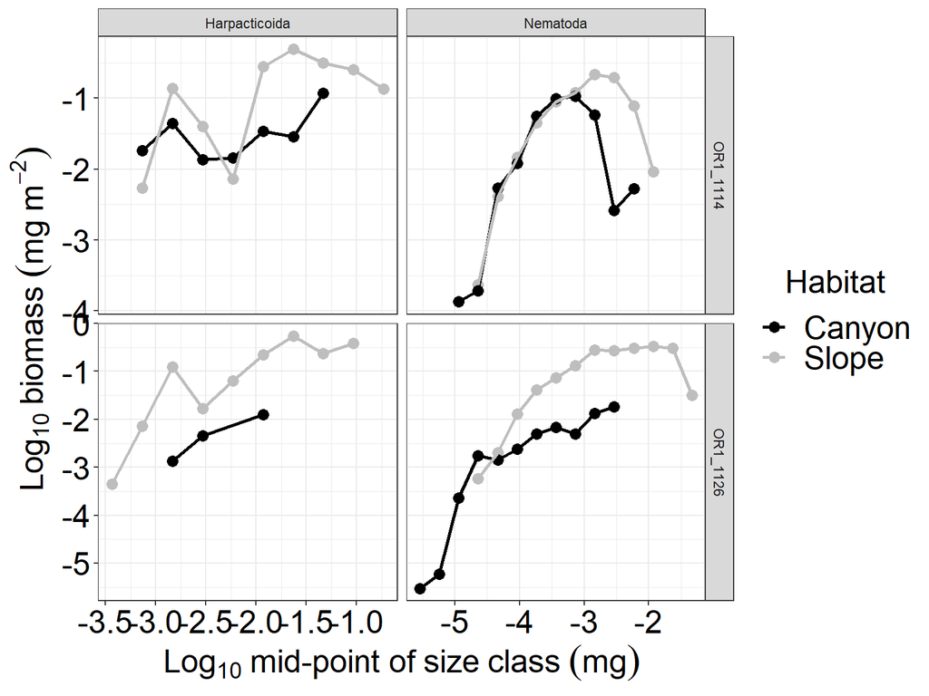

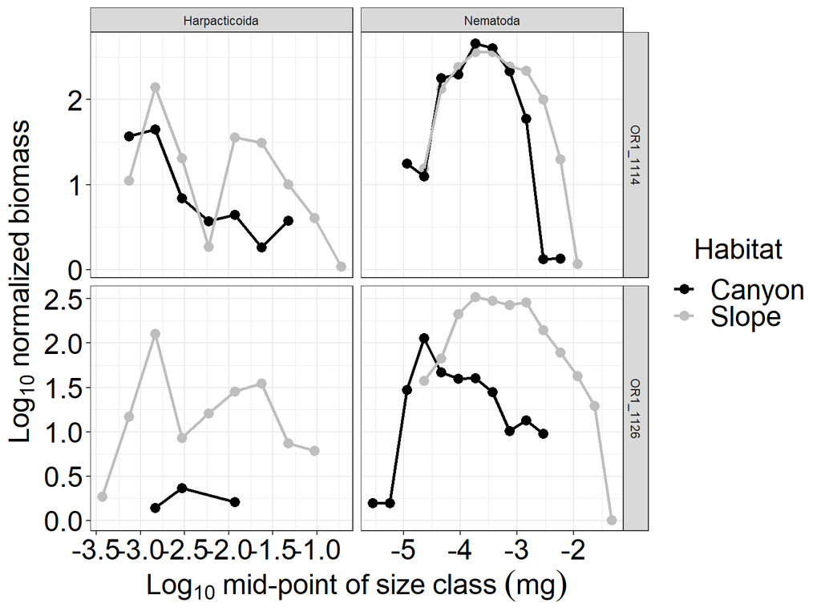

## 6.2 Size classes >= 1e-03

```
## $`OR1_1126|Slope|Nematoda`
## $`OR1_1126|Slope|Nematoda`$PLB.bMLE
## [1] -1.909436
##
## $`OR1_1126|Slope|Nematoda`$PLB.MLE.bConf
## [1] -2.033896 -1.789116
##
##
## $`OR1_1114|Slope|Nematoda`
## $`OR1_1114|Slope|Nematoda`$PLB.bMLE
## [1] -2.357276
##
## $`OR1_1114|Slope|Nematoda`$PLB.MLE.bConf
## [1] -2.605386 -2.119396
##
##
## $`OR1_1114|Slope|Harpacticoida`
## $`OR1_1114|Slope|Harpacticoida`$PLB.bMLE
## [1] -1.888929
##
## $`OR1_1114|Slope|Harpacticoida`$PLB.MLE.bConf
## [1] -2.055319 -1.733139
##
##
## $`OR1_1126|Slope|Harpacticoida`
## $`OR1_1126|Slope|Harpacticoida`$PLB.bMLE
## [1] -1.805674
##
## $`OR1_1126|Slope|Harpacticoida`$PLB.MLE.bConf
## [1] -1.973634 -1.647124
```

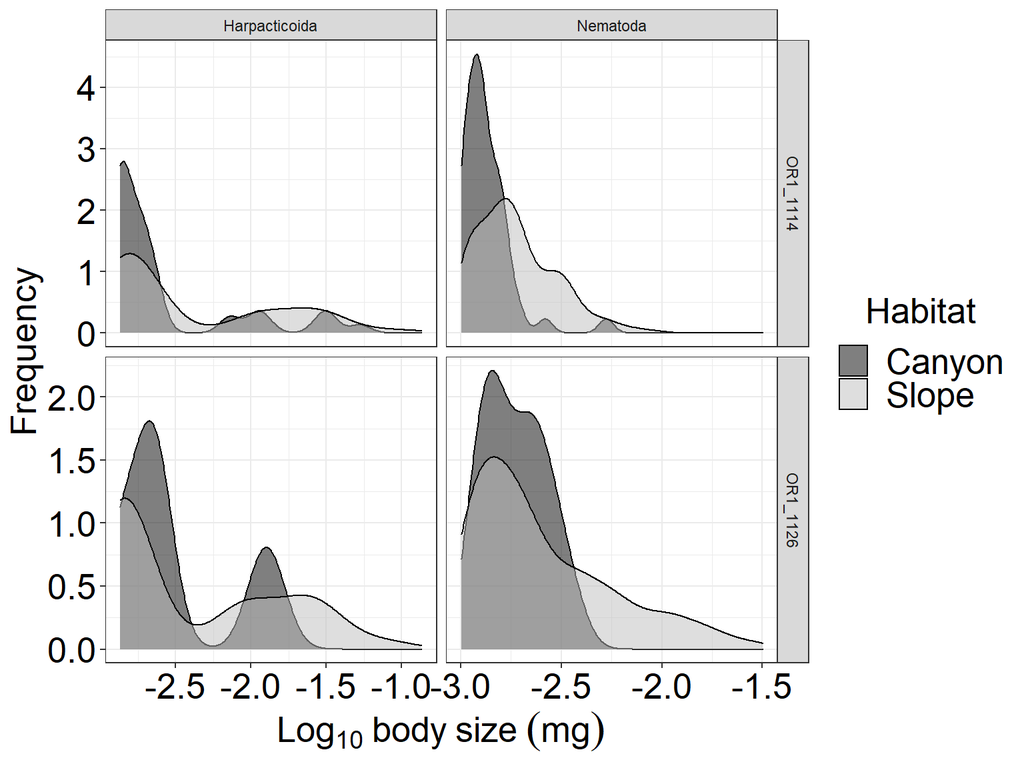

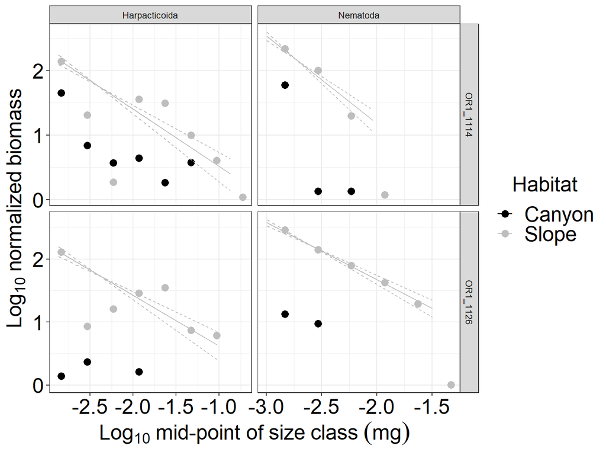

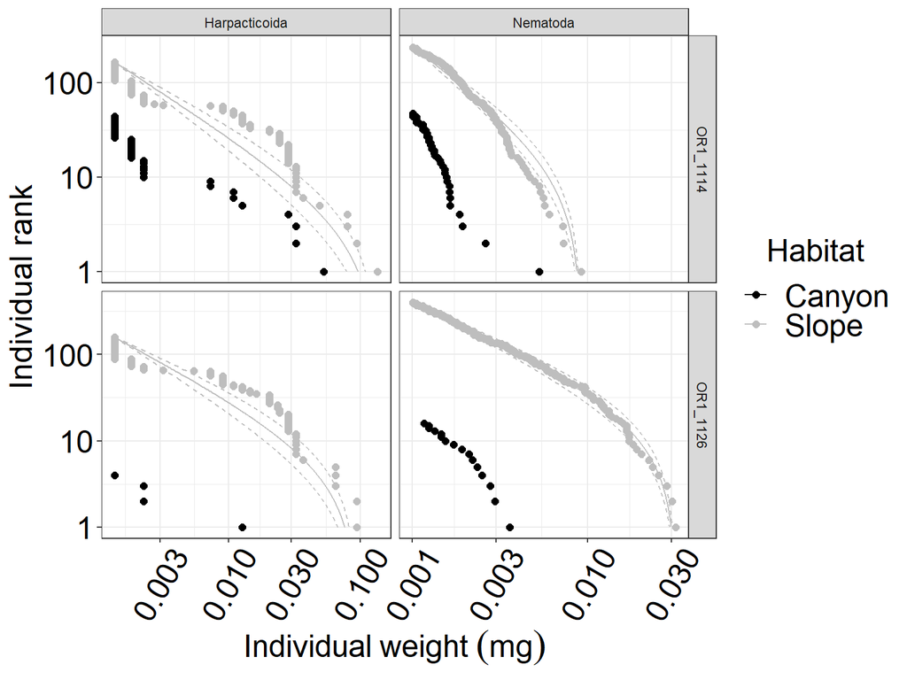

# 7 Mean body size of meiofauna

## 7.1 By cruise and habitat

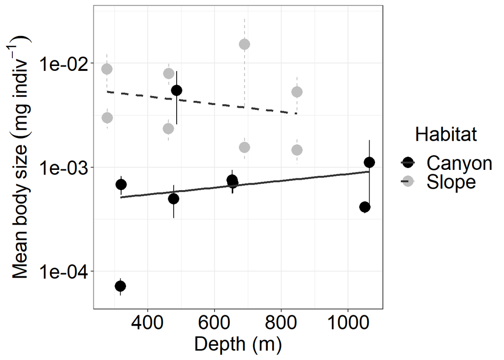

| Region | Habitat | Cruise | Station | Depth | n | Mean Size | SD | SE |
| --- | --- | --- | --- | --- | --- | --- | --- | --- |
| Gaoping | Canyon | OR1_1114 | GC1 | 320 | 321 | 0.00 | 0.002 | 0.000 |
| Gaoping | Canyon | OR1_1114 | GC2 | 478 | 155 | 0.00 | 0.002 | 0.000 |
| Gaoping | Canyon | OR1_1114 | GC3 | 653 | 340 | 0.00 | 0.004 | 0.000 |
| Gaoping | Canyon | OR1_1114 | GC4 | 1051 | 278 | 0.00 | 0.001 | 0.000 |
| Gaoping | Canyon | OR1_1126 | GC1 | 318 | 125 | 0.00 | 0.000 | 0.000 |
| Gaoping | Canyon | OR1_1126 | GC2 | 487 | 19 | 0.01 | 0.013 | 0.003 |
| Gaoping | Canyon | OR1_1126 | GC3 | 655 | 68 | 0.00 | 0.001 | 0.000 |
| Gaoping | Canyon | OR1_1126 | GC4 | 1065 | 18 | 0.00 | 0.003 | 0.001 |
| Gaoping | Slope | OR1_1114 | GS1 | 279 | 372 | 0.00 | 0.012 | 0.001 |
| Gaoping | Slope | OR1_1114 | GS2 | 462 | 289 | 0.00 | 0.009 | 0.001 |
| Gaoping | Slope | OR1_1114 | GS3 | 690 | 319 | 0.02 | 0.202 | 0.011 |
| Gaoping | Slope | OR1_1114 | GS4 | 848 | 350 | 0.01 | 0.038 | 0.002 |
| Gaoping | Slope | OR1_1126 | GS1 | 277 | 348 | 0.01 | 0.063 | 0.003 |
| Gaoping | Slope | OR1_1126 | GS2 | 463 | 436 | 0.01 | 0.039 | 0.002 |
| Gaoping | Slope | OR1_1126 | GS3 | 690 | 329 | 0.00 | 0.006 | 0.000 |
| Gaoping | Slope | OR1_1126 | GS4 | 848 | 316 | 0.00 | 0.007 | 0.000 |

## 7.2 By habitat

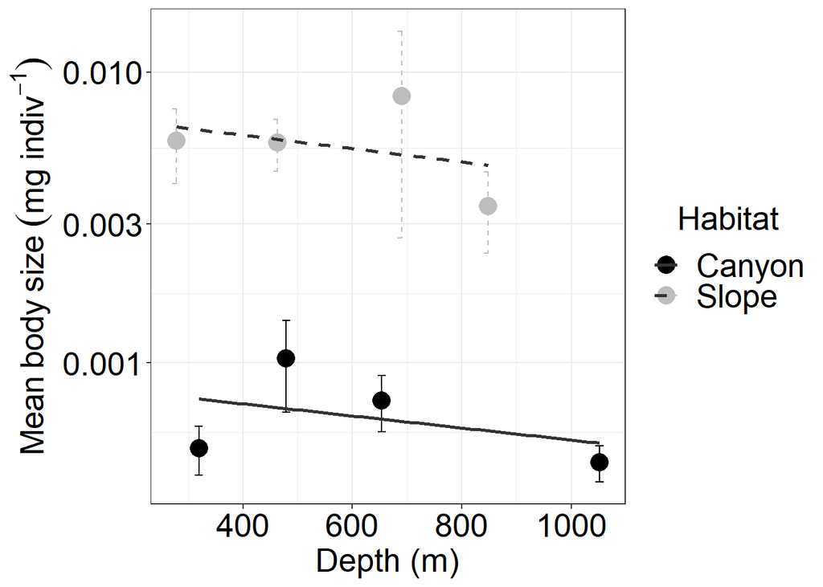

| Region | Habitat | Station | Depth | n | Mean Size | SD | SE |
| --- | --- | --- | --- | --- | --- | --- | --- |
| Gaoping | Canyon | GC1 | 319 | 446 | 0.00 | 0.002 | 0.000 |
| Gaoping | Canyon | GC2 | 479 | 174 | 0.00 | 0.005 | 0.000 |
| Gaoping | Canyon | GC3 | 653 | 408 | 0.00 | 0.003 | 0.000 |
| Gaoping | Canyon | GC4 | 1052 | 296 | 0.00 | 0.001 | 0.000 |
| Gaoping | Slope | GS1 | 278 | 720 | 0.01 | 0.045 | 0.002 |
| Gaoping | Slope | GS2 | 463 | 725 | 0.01 | 0.031 | 0.001 |
| Gaoping | Slope | GS3 | 690 | 648 | 0.01 | 0.142 | 0.006 |
| Gaoping | Slope | GS4 | 848 | 666 | 0.00 | 0.028 | 0.001 |